# Assignment 6

## Try to submit as an HTML file

Print your name below

```python
print("Sophia Xiao")
```

```
Sophia Xiao
```

Import the "pandas" and "matplotlib.pyplot" library

```python
# Write your answer here:

import pandas as pd
import matplotlib.pyplot as plt
```

(a) Compute function for each individual (map)

- Import the datset "data/investment.csv"
- Write a lambda function for $V = P/(1+r)$.
- Use `list(map(...))` to calculate $V$ for each row of the dataset

```python
# Write your own code here

investment_dataset = pd.read_csv("data/investment.csv")
print(investment_dataset.columns)

V_func = lambda P, r: P / (1+r)

investment_dataset["V"] = list(map(V_func, investment_dataset["P"],  investment_dataset["r"]))

investment_dataset
```

```
Index(['P', 'r'], dtype='object')
```

|  | P | r | V |
| --- | --- | --- | --- |
| 0 | 1000 | 0.01 | 990.099010 |
| 1 | 2000 | 0.02 | 1960.784314 |
| 2 | 500 | 0.03 | 485.436893 |
| 3 | 800 | 0.04 | 769.230769 |
| 4 | 400 | 0.08 | 370.370370 |

(b) Convert to upper case

- Create the following function to convert a string to upper case

$\quad$ `fn_upper = lambda x: x.upper()`

- Create a new column, "countryname_upper"  
  that converts "countryname" to upper case.

```python
# Write your own code here
fn_upper = lambda x : x.upper()

WDI2020 = pd.read_csv("data/wdi_2020.csv")

WDI2020["countryname_upper"] = list(map(fn_upper, WDI2020["countryname"]))


WDI2020
```

|  | year | yearcode | countryname | countrycode | prop_urbanpopulation | countryname_upper |
| --- | --- | --- | --- | --- | --- | --- |
| 0 | 2020 | YR2020 | Afghanistan | AFG | 26.026000 | AFGHANISTAN |
| 1 | 2020 | YR2020 | Africa Eastern and Southern | AFE | 36.828301 | AFRICA EASTERN AND SOUTHERN |
| 2 | 2020 | YR2020 | Africa Western and Central | AFW | 47.857831 | AFRICA WESTERN AND CENTRAL |
| 3 | 2020 | YR2020 | Albania | ALB | 62.112000 | ALBANIA |
| 4 | 2020 | YR2020 | Algeria | DZA | 73.733000 | ALGERIA |
| ... | ... | ... | ... | ... | ... | ... |
| 261 | 2020 | YR2020 | West Bank and Gaza | PSE | 76.719000 | WEST BANK AND GAZA |
| 262 | 2020 | YR2020 | World | WLD | 56.063764 | WORLD |
| 263 | 2020 | YR2020 | Yemen, Rep. | YEM | 37.908000 | YEMEN, REP. |
| 264 | 2020 | YR2020 | Zambia | ZMB | 44.629000 | ZAMBIA |
| 265 | 2020 | YR2020 | Zimbabwe | ZWE | 32.242000 | ZIMBABWE |

266 rows × 6 columns

For questions (b)-(d), read "data/wdi_2020.csv"

(c) Extract sorted elements from a dataset

- Sort by "prop_urbanpopulation" in descending order
- Subset the 5 countries with the highest urban population

```python
# Write your code here
WDI2020.sort_values("prop_urbanpopulation", ascending = False, inplace = True)

WDI2020

highest_5_countries = WDI2020.iloc[:5, :] # slice row 0-5 and all columns

highest_5_countries
```

|  | year | yearcode | countryname | countrycode | prop_urbanpopulation | countryname_upper |
| --- | --- | --- | --- | --- | --- | --- |
| 212 | 2020 | YR2020 | Singapore | SGP | 100.0 | SINGAPORE |
| 147 | 2020 | YR2020 | Macao SAR, China | MAC | 100.0 | MACAO SAR, CHINA |
| 40 | 2020 | YR2020 | Cayman Islands | CYM | 100.0 | CAYMAN ISLANDS |
| 90 | 2020 | YR2020 | Gibraltar | GIB | 100.0 | GIBRALTAR |
| 103 | 2020 | YR2020 | Hong Kong SAR, China | HKG | 100.0 | HONG KONG SAR, CHINA |

(d) Subset elements with query

- Compute the median of "prop_urbanpopulation"
- Use ".query()" to subset countries with  
  "prop_urbanpopulation" above the median

```python
# Write your own code here

median_prop_urbanpopulation = WDI2020["prop_urbanpopulation"].median()
# the .median method for the pd dataframe column disregards NaN values.
print(median_prop_urbanpopulation)

above_average_urban_population = WDI2020.query("prop_urbanpopulation > @median_prop_urbanpopulation")
# use a boolean statement in parentheses. No need to use parentheses for variable name.

above_average_urban_population
```

```
60.69872843
```

|  | year | yearcode | countryname | countrycode | prop_urbanpopulation | countryname_upper |
| --- | --- | --- | --- | --- | --- | --- |
| 212 | 2020 | YR2020 | Singapore | SGP | 100.000000 | SINGAPORE |
| 147 | 2020 | YR2020 | Macao SAR, China | MAC | 100.000000 | MACAO SAR, CHINA |
| 40 | 2020 | YR2020 | Cayman Islands | CYM | 100.000000 | CAYMAN ISLANDS |
| 90 | 2020 | YR2020 | Gibraltar | GIB | 100.000000 | GIBRALTAR |
| 103 | 2020 | YR2020 | Hong Kong SAR, China | HKG | 100.000000 | HONG KONG SAR, CHINA |
| ... | ... | ... | ... | ... | ... | ... |
| 3 | 2020 | YR2020 | Albania | ALB | 62.112000 | ALBANIA |
| 84 | 2020 | YR2020 | French Polynesia | PYF | 61.975000 | FRENCH POLYNESIA |
| 160 | 2020 | YR2020 | Middle East & North Africa (excluding high inc... | MNA | 61.892321 | MIDDLE EAST & NORTH AFRICA (EXCLUDING HIGH INC... |
| 161 | 2020 | YR2020 | Middle East & North Africa (IDA & IBRD countries) | TMN | 61.717344 | MIDDLE EAST & NORTH AFRICA (IDA & IBRD COUNTRIES) |
| 46 | 2020 | YR2020 | China | CHN | 61.428000 | CHINA |

131 rows × 6 columns

(e) Plot by category

- Read "data/wdi_urban.csv"  
  This contains data from 1980 and 2020
- Create a list with the unique values of "year"
- Create a plot with a ...
  - Histogram of "prop_urbanpopulation"  
    for each year
  - Set the histogram option `alpha = 0.5` for transparency
  - All the histograms should be overlapping
  - Create a legend with the list of years
  - Label the axes and the title

What do we learn from the graph?

Compared to in 1980, in 2020 more countries had a higher proportion of their populations living in cities. This makes sense because development is accompanied by urbanization.

HINT: See the example at the end of Lecture 10

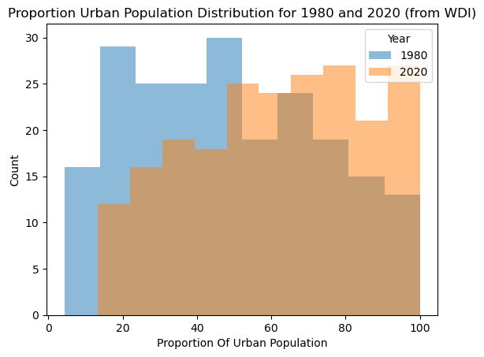

```python
WDIURBAN = pd.read_csv("data/wdi_urban.csv")

# Get unique categories for "year"
unique_years = pd.unique(WDIURBAN["year"])

# Use a for loop to plot a scatter plot between "weight" and "acceleration"
# for each category. Each plot  will have a different color

for category in unique_years:
    df   = WDIURBAN.query("year == @category")
    plt.hist(df["prop_urbanpopulation"], alpha = 0.5)

# Add labels and a legends
plt.xlabel("Proportion Of Urban Population")
plt.ylabel("Count")
plt.legend(labels = unique_years,
           title  = "Year")
plt.title("Proportion Urban Population Distribution for 1980 and 2020 (from WDI)")

plt.show()
```